# **UN INCONTRO DI BOX OFFICE**

Nicolò Bonacorsi

2022-05-17

## Introduzione e specifica sulle variabili

> **Premessa: ogni dato statistico presente nelle seguenti pagine è stato calcolato tramite il supporto di RStudio**

#### **Nel seguente report analizzeremo i dati provenienti da un dataset statistico caricato sul sito https://www.kaggle.com/datasets al seguente indirizzo https://www.kaggle.com/datasets/leonardopena/marvel-vs-dc . Si tratta di un dataset relativo al confonto su vari livelli dei film millennial di Marvel e DCU, due delle case cinematografiche fondamentali nell’universo** film HERO**.**

#### **La quasi totalità dei dati è stata estrapolata dal sito https://www.imdb.com/ , un database online di informazioni relative a film ed in generis al mondo cinematografico.**

#### **E’ stato però necessario diversificare le fonti, per quanto riguarda una delle variabili analizzate, andandone a reperire i dati sul sito https://www.metacritic.com/ che trasforma ogni recensione riguardante un determinato film (sia quelle scritte da critici specializzati che da comuni utenti privati) in un punteggio numerico, andandone ,successivamente, a calcolare la media ponderata.**

#### **Cercheremo , quindi, tramite strumenti matematici, statistici ed il supporto informatico, di sintetizzare al meglio i dati relativi a più variabili e più unità statistiche, in modo da aver una visione più rigorosa e informativa dell’insieme.**

## Nome dataset originale, nome dataset nuovo e nomi script di R

### **Nome dataset originale:**

> **db.csv**

### **Nome dataset nuovo:**

> **MCU_vs_DCU.df**

### **Nomi script:**

> MCU_vs_DCU_df_1

> Var_Original_Title_2

> Var_Company

> Var_Film_rate_IMDB_4

> Var_film_Metascore_5

> Var_Minutes_6

> Var_date_release_7

> Var_Film_Budget_8

> Var_Opening_weekend_USA_9

> Var_Gross_USA_10

> Var_Gross_World_11

# Presentazione delle variabili

#### Il dataset è composto da 10 variabili di cui 2 qualitative e 8 quantitative:

#### *Original Title: la variabile, di tipo qualitativo, è stata codificata con*

> Original.Title

#### ed indica il titolo originale del film X.

#### *Company : la variabile, di tipo qualitativo, è stata codificata con*

> Company

#### ed indica la casa cinematografica di appartenenza del film X.

#### *Rate: la variabile,di tipo quantitativo, è stata codificata con*

> Film.Rate.IMDB

#### ed indica il voto attribuito al film X da IMDB (in decimi).

#### *Metascore: la variabile, di tipo quantitativo, è stata codificata con*

> Film.Rate.Metascore

#### ed indica il voto attribuito al film X da Metascore (in centesimi).

#### *Minutes: la variabile, di tipo quantitativo, è stata codificata con*

> Film.minutes

#### ed indica la durata i minuti del film X.

#### *Release: la variabile, di tipo quantitativo, è stata codificata con*

> date.release

#### ed indica l’anno di uscita nelle sale cinematografiche del film X.

#### *Budget : la variabile,di tipo quantitativo, è stata codificata con*

> Budget

#### ed indica il budget stanziato dalla casa cinematografica Y per produrre il film X.

#### *Opening.Weekend.USA: la variabile, di tipo quantitativo, è stata codificata con*

> Opening.Weekend.USA

#### ed indica il profitto realizzato nel primo weekend di uscita nelle sale USA dal film X.

#### *Gross.USA: la variabile, di tipo quantitativo, è stata codificata con*

> Gross.USA

#### ed indica i ricavi del film X meno i costi per realizzarlo ,al lordo delle tasse statali , negli USA.

#### *Gross.Worldwide: la variabile, di tipo quantitativo,è stata codificata con*

> Gross.World

#### ed indica i ricavi del film X meno i costi per realizzarlo ,al lordo delle tasse statali ,nel mondo.

# Analisi marginali e congiunte

## **VARIABILE ORIGINAL.TITLE**

```
 [1] "Iron Man"                            "The Incredible Hulk"
 [3] "Iron Man 2"                          "Thor"
 [5] "Captain America: The First Avenger"  "The Avengers"
 [7] "Iron Man Three"                      "Thor: The Dark World"
 [9] "Captain America: The Winter Soldier" "Guardians of the Galaxy"
[11] "Avengers: Age of UltronÂ "           "Ant-Man"
[13] "Captain America: Civil War"          "Doctor Strange"
[15] "Guardians of the Galaxy Vol. 2"      "Spider-Man: Homecoming"
[17] "Thor:Ragnarok"                       "Black Panther"
[19] "Avengers: Infinity War"              "Ant-Man and the Wasp"
[21] "Captain Marvel"                      "Avengers: Endgame"
[23] "Spider-Man: Far from Home"           "Catwoman"
[25] "Batman Begins"                       "Superman Returns"
[27] "The Dark Knight"                     "Watchmen"
[29] "Jonah Hex"                           "Green Lantern"
[31] "The Dark Knight Rises"               "Man of Steel"
[33] "Batman v Superman: Dawn of Justice"  "Suicide Squad"
[35] "Wonder Woman"                        "Justice League"
[37] "Aquaman"                             "Shazam!"
[39] "Joker"
```

```
 chr [1:39] "Iron Man" "The Incredible Hulk" "Iron Man 2" "Thor" ...
```

#### *Noto quindi che le osservazioni sono 39.*

## **VARIABILE COMPANY**

```
 [1] "Marvel" "Marvel" "Marvel" "Marvel" "Marvel" "Marvel" "Marvel" "Marvel"
 [9] "Marvel" "Marvel" "Marvel" "Marvel" "Marvel" "Marvel" "Marvel" "Marvel"
[17] "Marvel" "Marvel" "Marvel" "Marvel" "Marvel" "Marvel" "Marvel" "DC"
[25] "DC"     "DC"     "DC"     "DC"     "DC"     "DC"     "DC"     "DC"
[33] "DC"     "DC"     "DC"     "DC"     "DC"     "DC"     "DC"
```

```
 chr [1:39] "Marvel" "Marvel" "Marvel" "Marvel" "Marvel" "Marvel" "Marvel" ...
```

#### *La variabile Company presenta,quindi, 2 modalità, come ci aspettavamo dalla natura del dataset scaricato*

### *Creo , quindi, un grafico a barre che mi permetta di capire sul totale delle osservazioni qual è la probabilità che pescando un film X, casualmente , esso sia stato prodotto da Marvel o da DC.*

```
[1] "DC"     "Marvel"
```

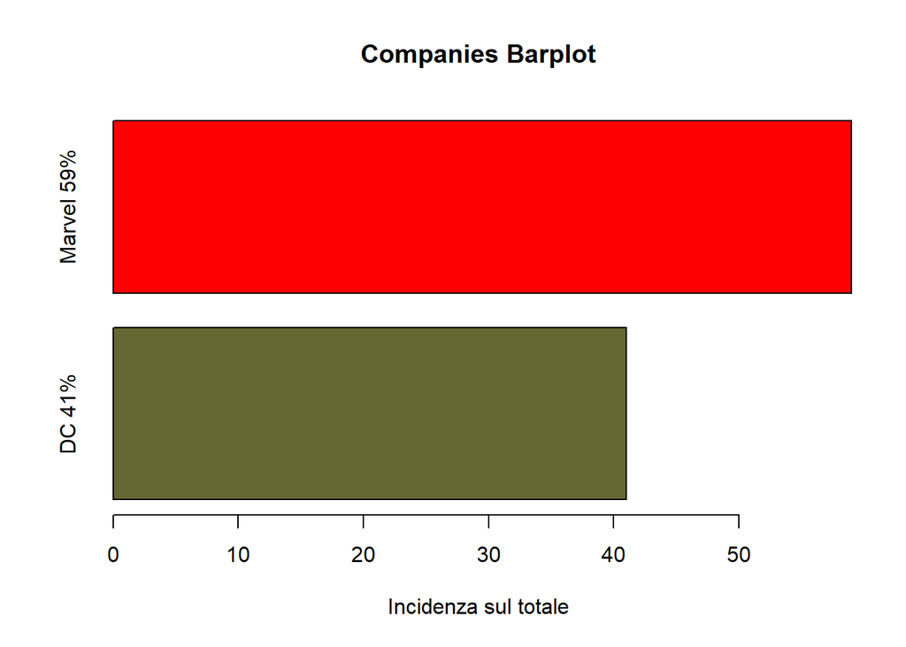

## **VARIABILE FILM.RATE.IMDB**

### *Analizzo il summary della generica variabile Film.Rate.IMDB per dedurre il range di valori che assume*

```r
# variabile nella quarta colonna

MCU_vs_DCU.df[,4]
```

```
 [1] 7.9 6.7 7.0 7.0 6.9 8.0 7.2 6.9 7.7 8.0 7.3 7.3 7.8 7.5 7.6 7.4 7.9 7.3 8.5
[20] 7.1 6.9 8.5 7.6 3.3 8.2 6.0 9.0 7.6 4.7 5.5 8.4 7.1 6.5 6.0 7.4 6.4 7.0 7.1
[39] 8.7
```

```r
Film.Rate.IMDB=MCU_vs_DCU.df[,4]

#3.1 summary
summary(Film.Rate.IMDB)
```

```
   Min. 1st Qu.  Median    Mean 3rd Qu.    Max.
  3.300   6.900   7.300   7.203   7.850   9.000
```

### *Analizzo il summary della generica variabile Film.Rate.IMDB categorizzata in base alla variabile Company per dedurre il range di valori che assume.*

#### Marvel

```
   Min. 1st Qu.  Median    Mean 3rd Qu.    Max.
  6.700   7.050   7.400   7.478   7.850   8.500
```

#### DC

```
   Min. 1st Qu.  Median    Mean 3rd Qu.    Max.
  3.300   6.000   7.050   6.806   7.750   9.000
```

### *Creiamo ,quindi, boxplot e istogrammi che ci facciano intuire in maniera piu chiara la distribuzione della variabile Film.Rate.IMDB generica e di quella dei voti IMDB relativamente ai film Marvel DC.*

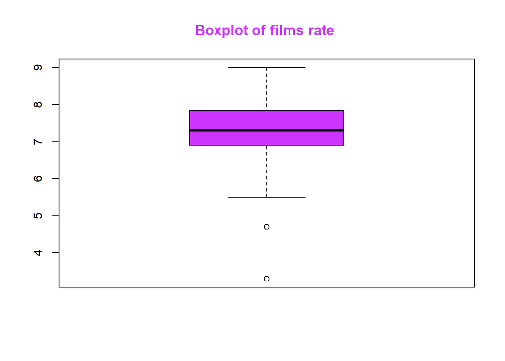

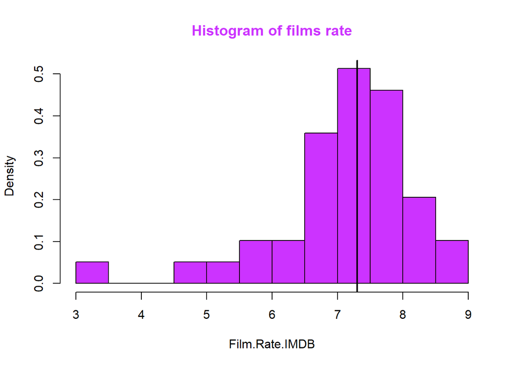

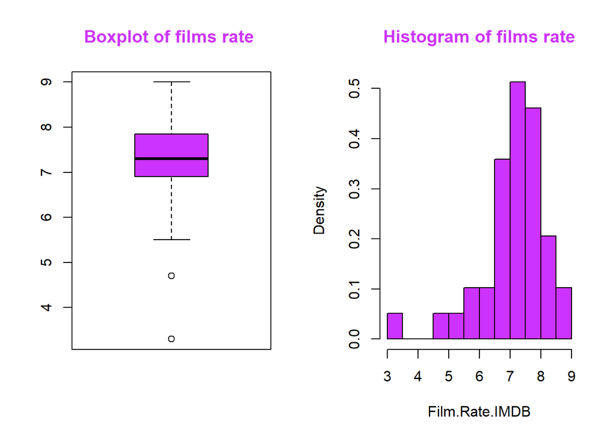

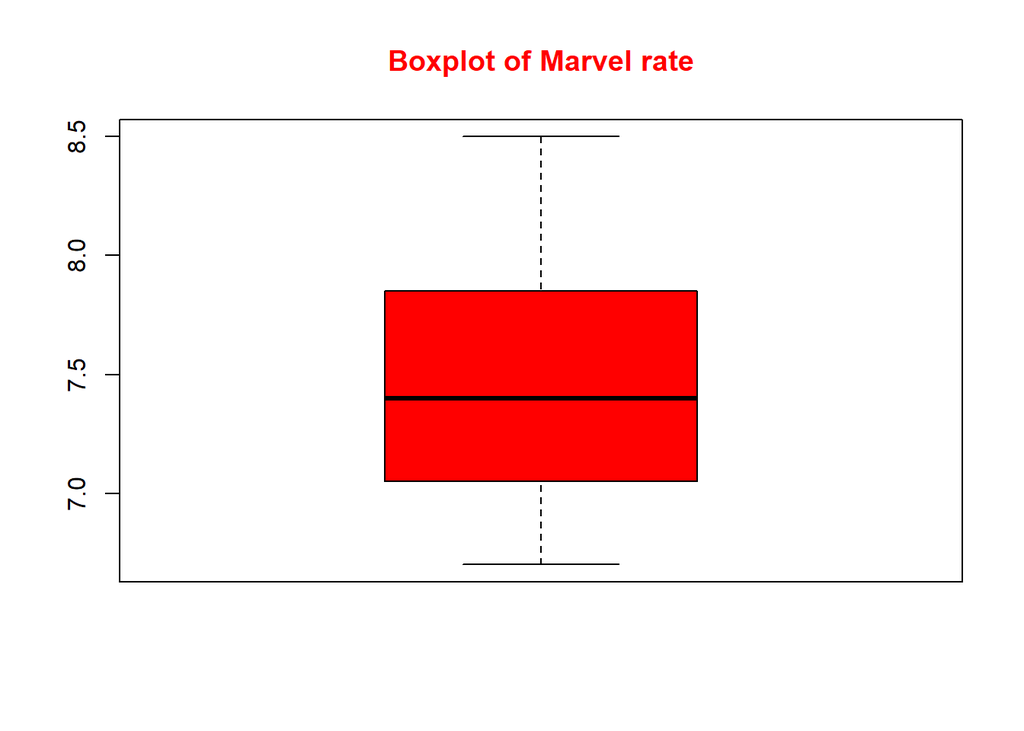

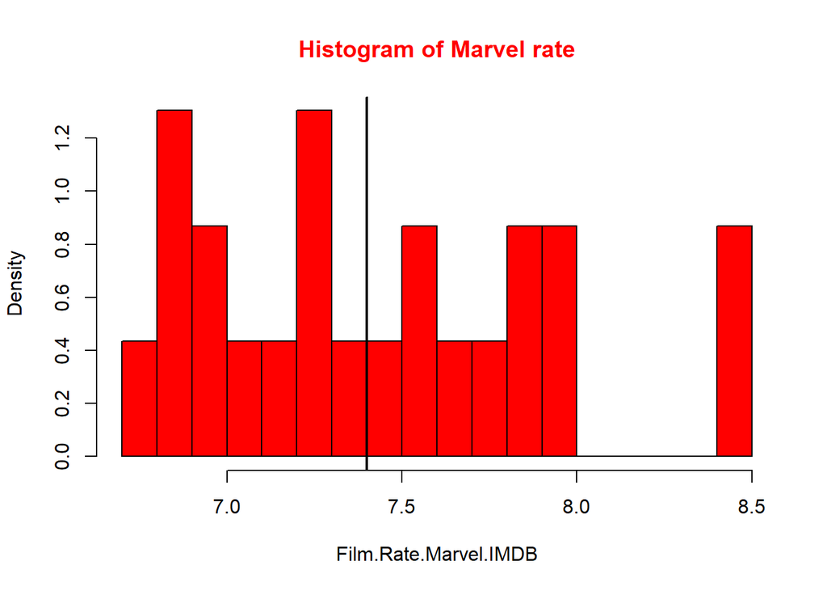

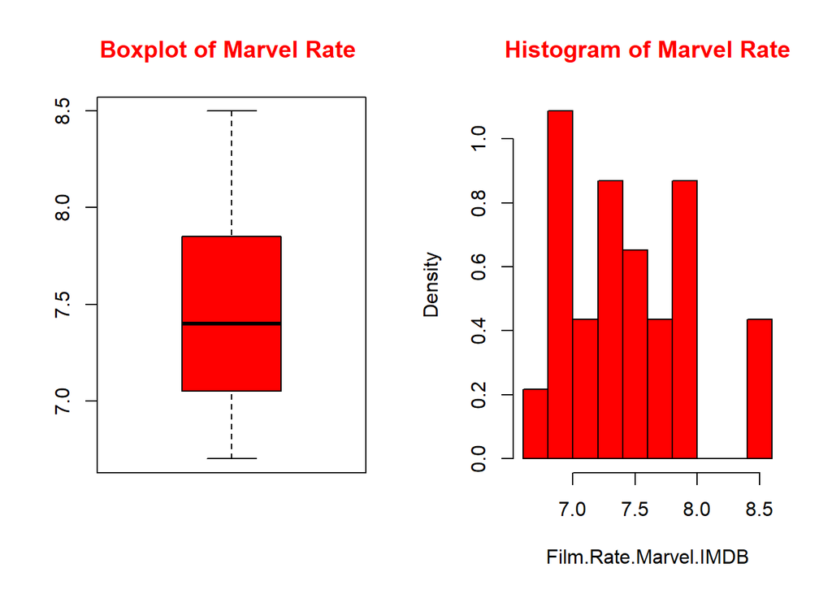

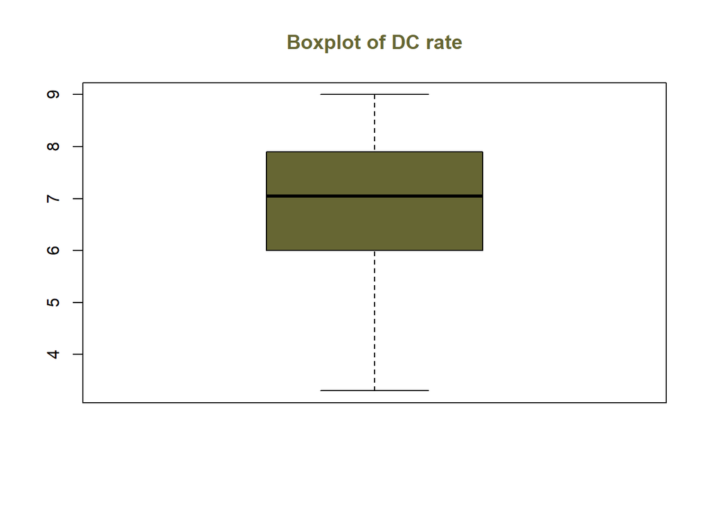

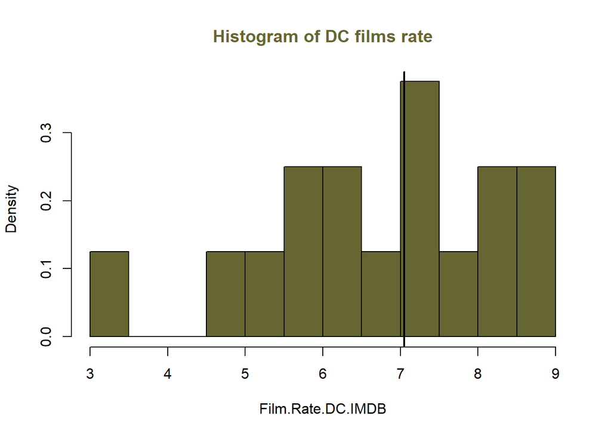

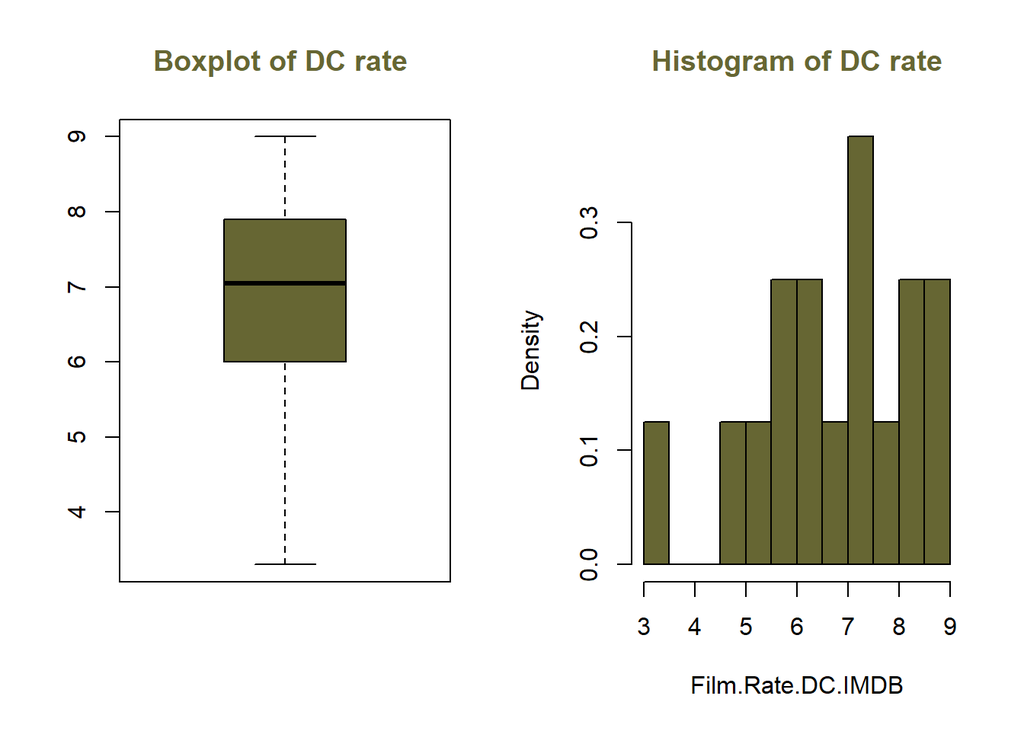

#### *E’ difficile confrontare boxplot e istogrammi che si distribuiscono su scale differenti.*

### *E’ necessario affiancare i boxplot del Film.Rate.IMBD di Marvel e DC, in modo da valutare la distribuzione avendo come riferimento la stessa scala*

```
$DC
   Min. 1st Qu.  Median    Mean 3rd Qu.    Max.
  3.300   6.000   7.050   6.806   7.750   9.000

$Marvel
   Min. 1st Qu.  Median    Mean 3rd Qu.    Max.
  6.700   7.050   7.400   7.478   7.850   8.500
```

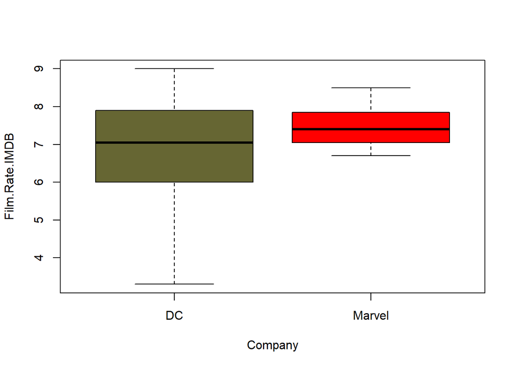

#### *Noto che le osservazioni della variabile Film.Rate.IMDB si distribuiscono in maniera nettamente differente:*

#### -I minimi ed i massimi dei due boxplot presentano disguaglianza soprattutto sui minimi:

> Il voto del film Marvel che ha ottenuto punteggio minimo è nettamente maggiore di quello ottenuto dal film DC. Il film Marvel che ottenuto punteggio maggiore ha ,però, ottenuto una valutazione minore rispetto a quello DC.

#### -Le due mediane differiscono, anche se di poco:

> I film Marvel hanno come voto mediano un voto più alto rispetto a quelli DC

#### -Il primo quartile presenta una netta disparità:

> Le osservazioni dei voti per i film Marvel sono piu’ concentrate attorno alla mediana rispetto a quelle DC

#### -Entrambe le scatole dei boxplot sono distribuite in maniera asimmetrica. Quella piu evidente è quella dei film DC

> I voti dei film Marvel hanno una distribuzione maggiormente simmetrica e uniforme rispetto a quelli DC

### *Creo un istorgamma che metta in relazione la variabile Film.Rate.IMDB e la variabile Company*

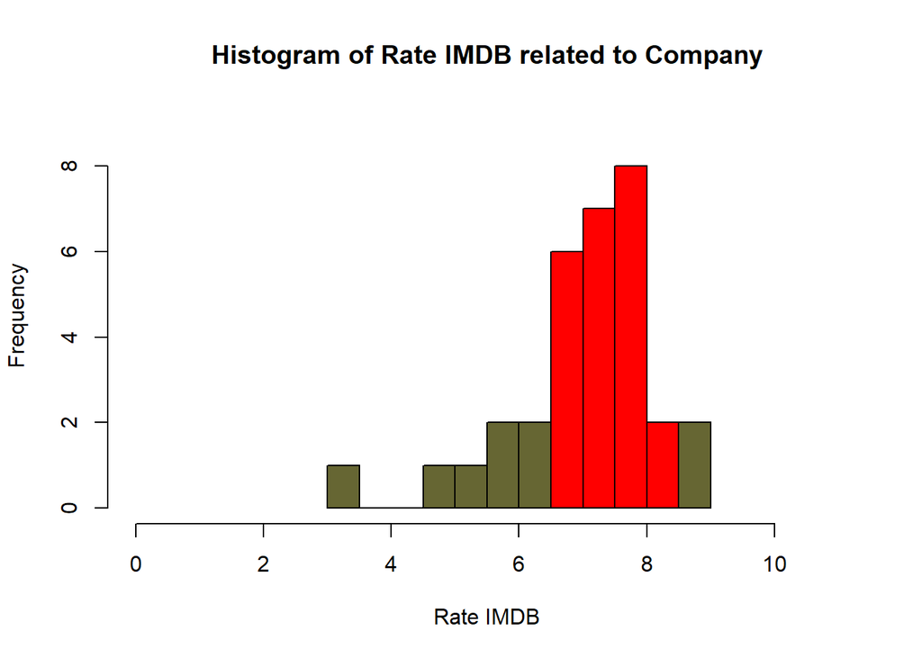

### *Misuro quindi la connessione che c’è tra l’appartenenza ad una determinata casa cinematografica e il voto ottenuto da IMDB*

```r
#misuro eta quadro tra variabile company e variabile rate

aov.IMDB=summary(aov(MCU_vs_DCU.df$Rate~MCU_vs_DCU.df$Company))

dev.IMDB=aov.IMDB[[1]]$`Sum Sq`

eta.quadro.IMDB=dev.IMDB[1]/sum(dev.IMDB)

eta.quadro.IMDB
```

```
[1] 0.09708961
```

#### *Si deduce che la dipendenza in media dalla variabile Company spiega solo il 9.7% della variabilità totale della variabile Film.Rate.IMDB*

### *Quale film ha ottenuto punteggio minore e quale quello maggiore? A che casa cinematografica appartegono?*

```
   Min. 1st Qu.  Median    Mean 3rd Qu.    Max.
  3.300   6.900   7.300   7.203   7.850   9.000
```

```
[1] "Catwoman"
```

```
[1] "DC"
```

```
[1] "The Dark Knight"
```

```
[1] "DC"
```

### *Qual è il film Marvel che ha ottenuto punteggio minore e quale quello maggiore? E quelli DC?*

```
   Min. 1st Qu.  Median    Mean 3rd Qu.    Max.
  6.700   7.050   7.400   7.478   7.850   8.500
```

```
[1] "The Incredible Hulk"
```

```
[1] "Avengers: Infinity War" "Avengers: Endgame"
```

```
   Min. 1st Qu.  Median    Mean 3rd Qu.    Max.
  3.300   6.000   7.050   6.806   7.750   9.000
```

```
[1] "Catwoman"
```

```
[1] "The Dark Knight"
```

## **VARIABILE FILM.RATE.METASCORE**

### *Analizzo il summary della generica variabile Film.Rate.Metascore per dedurre il range di valori che assume.*

```
 [1] 79 61 57 57 66 69 62 54 70 76 66 64 75 72 67 73 74 88 68 70 64 78 69 27 70
[26] 72 84 56 33 39 78 55 44 40 76 45 55 71 59
```

### *Analizzo il summary della generica variabile Film.Rate.Metascore categorizzata in base alla variabile Company per dedurre il range di valori che assume.*

#### Marvel

```
   Min. 1st Qu.  Median    Mean 3rd Qu.    Max.
  54.00   64.00   69.00   68.65   73.50   88.00
```

#### DC

```
   Min. 1st Qu.  Median    Mean 3rd Qu.    Max.
  27.00   43.00   55.50   56.50   71.25   84.00
```

### *Creiamo quindi boxplot e istogrammi che ci facciano intuire in maniera piu chiara la distribuzione dei voti generici, dei voti per i film Marvel e di quelli per i film DC.*

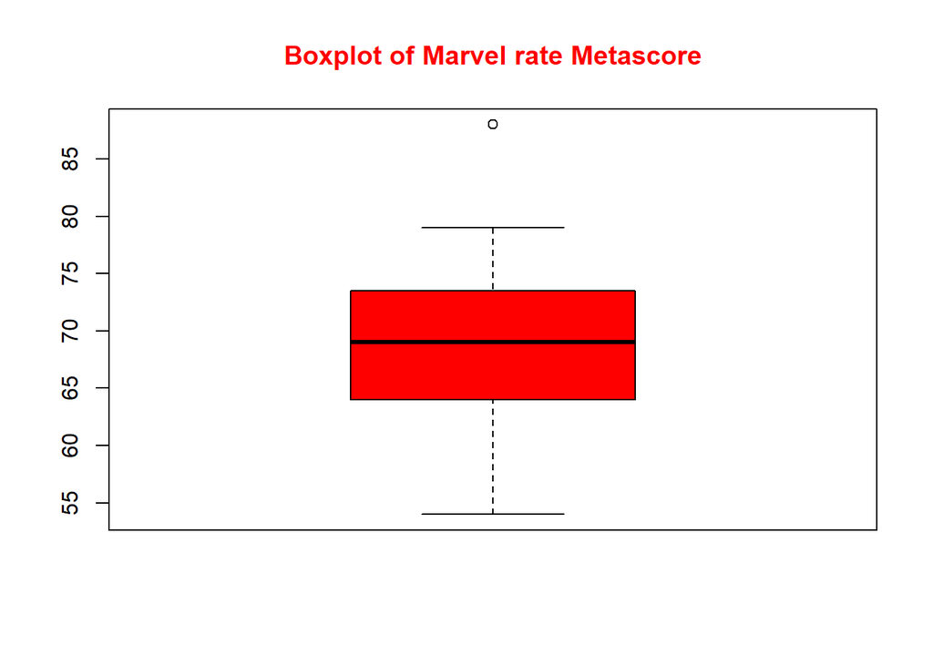

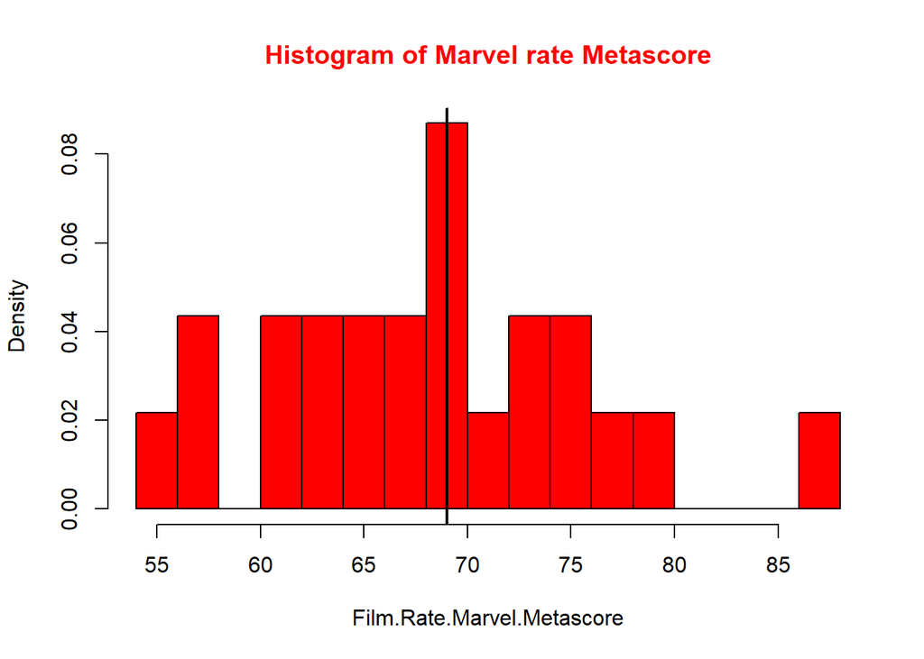

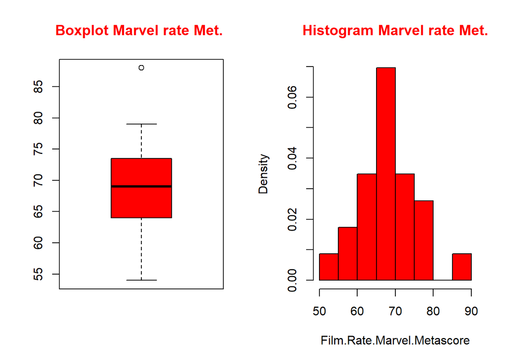

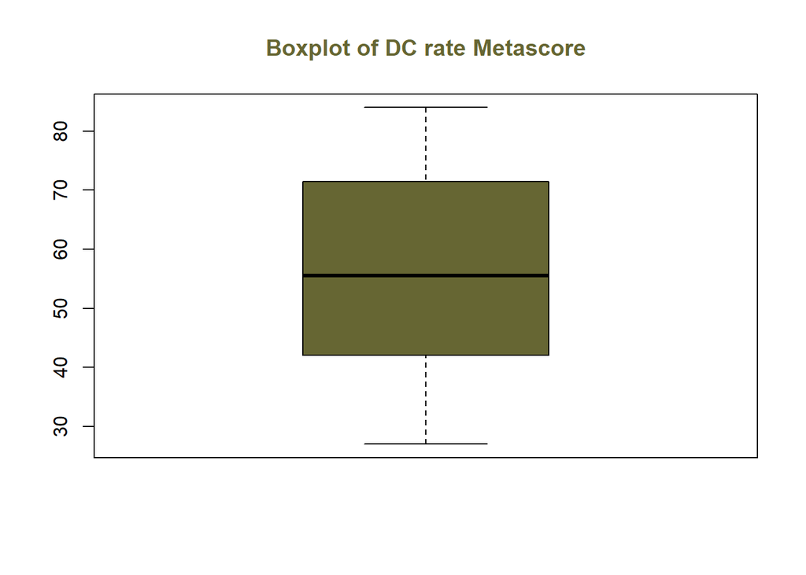

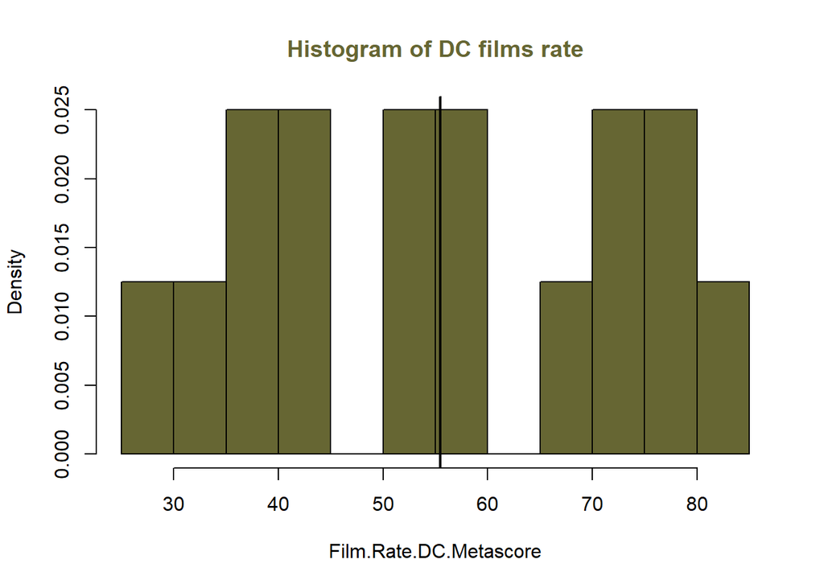

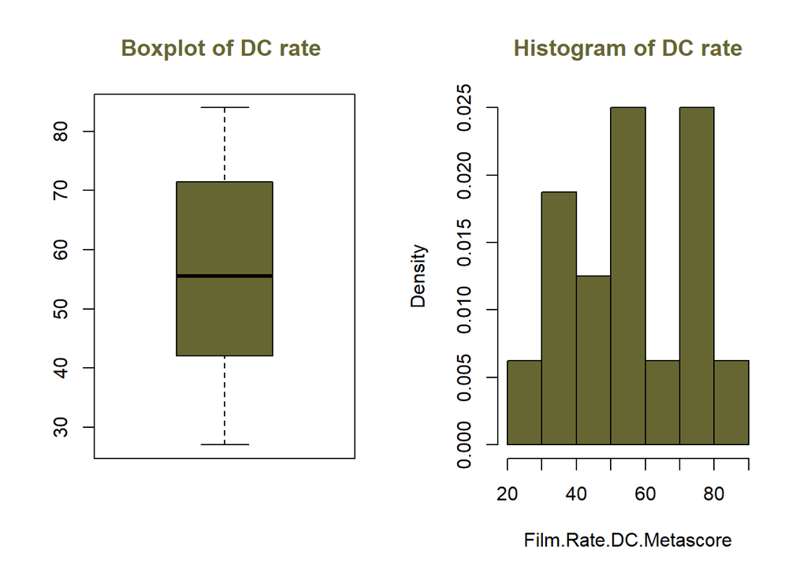

#### *E’ difficile confrontare boxplot e istogrammi che si distribuiscono su scale differenti.*

### *E’ necessario affiancare i boxplot del Film.Rate.Metascore di Marvel e DC*

```
$DC
   Min. 1st Qu.  Median    Mean 3rd Qu.    Max.
  27.00   43.00   55.50   56.50   71.25   84.00

$Marvel
   Min. 1st Qu.  Median    Mean 3rd Qu.    Max.
  54.00   64.00   69.00   68.65   73.50   88.00
```

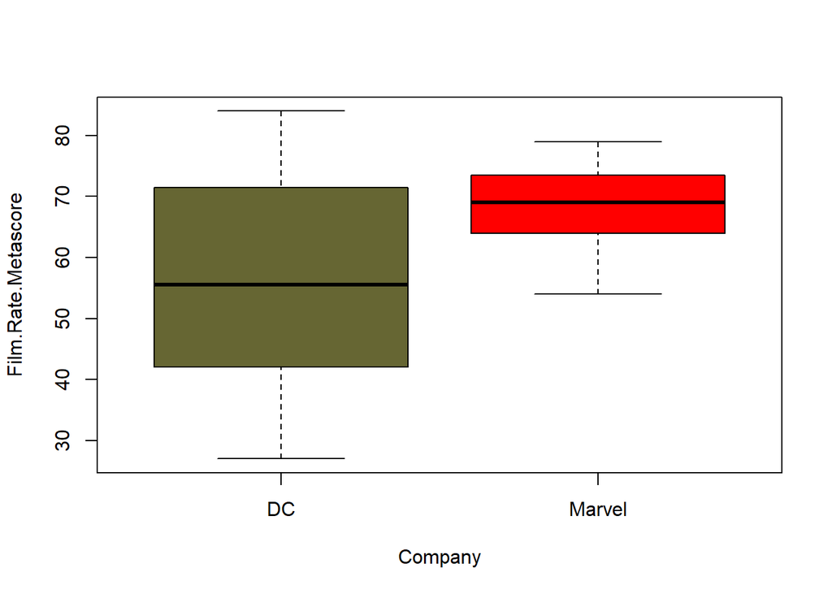

#### -Le due mediane differiscono:

> I film Marvel hanno voto mediano piu alto di quello dei film DC

#### -Il primo quartile presenta una netta disparità:

> La maggior parte delle osservazioni Marvel riporta come Metascore una valutazione molto piu conentrata attorno alla mediana rispetto ai film DC. Si nota,quindi, che la variabile Film.Rate.Metascore è molto più concentrata attorno ad uno specifico valore per i film Marvel.

### *Creo un istorgamma che metta in relazione la variabile Film.Rate.Metascore e la variabile Company*

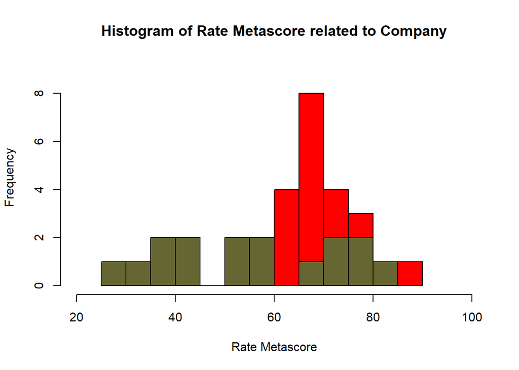

### *Misuro quindi la connessione che c’è tra l’appartenenza ad una determinata casa cinematografica e il voto Metascore*

```r
#misuro eta quadro tra variabile company e variabile Metascore

aov.Metascore=summary(aov(MCU_vs_DCU.df$Metascore~MCU_vs_DCU.df$Company))

dev.Metascore=aov.Metascore[[1]]$`Sum Sq`

eta.quadro.Metascore=dev.Metascore[1]/sum(dev.Metascore)
eta.quadro.Metascore
```

```
[1] 0.190866
```

#### *Si deduce che la dipendenza in media dalla variabile Company spiega solo il 19.1% della variabilità totale della variabile Film.Rate.Metascore.*

### *Qual è il titolo del film che ha ottenuto Metascore minore e maggiore? A quale Company appartiene?*

```
   Min. 1st Qu.  Median    Mean 3rd Qu.    Max.
  27.00   56.50   67.00   63.67   72.50   88.00
```

```
[1] "Catwoman"
```

```
[1] "DC"
```

```
[1] "Black Panther"
```

```
[1] "Marvel"
```

### *Qual è il titolo del film Marvel che ha ottenuto Metascore minore e maggiore? E quello DC?*

```
   Min. 1st Qu.  Median    Mean 3rd Qu.    Max.
  54.00   64.00   69.00   68.65   73.50   88.00
```

```
[1] "Thor: The Dark World"
```

```
[1] "Black Panther"
```

```
   Min. 1st Qu.  Median    Mean 3rd Qu.    Max.
  27.00   43.00   55.50   56.50   71.25   84.00
```

```
[1] "Catwoman"
```

```
[1] "The Dark Knight"
```

### *Affianco ,ora, i boxplot delle variabili Film.Rate.IMDB e Film.Rate.Metascore categorizzati per company, normalizzando,prima, la variabile Film.Rate.Metascore in un intervallo tra 0 e 10*

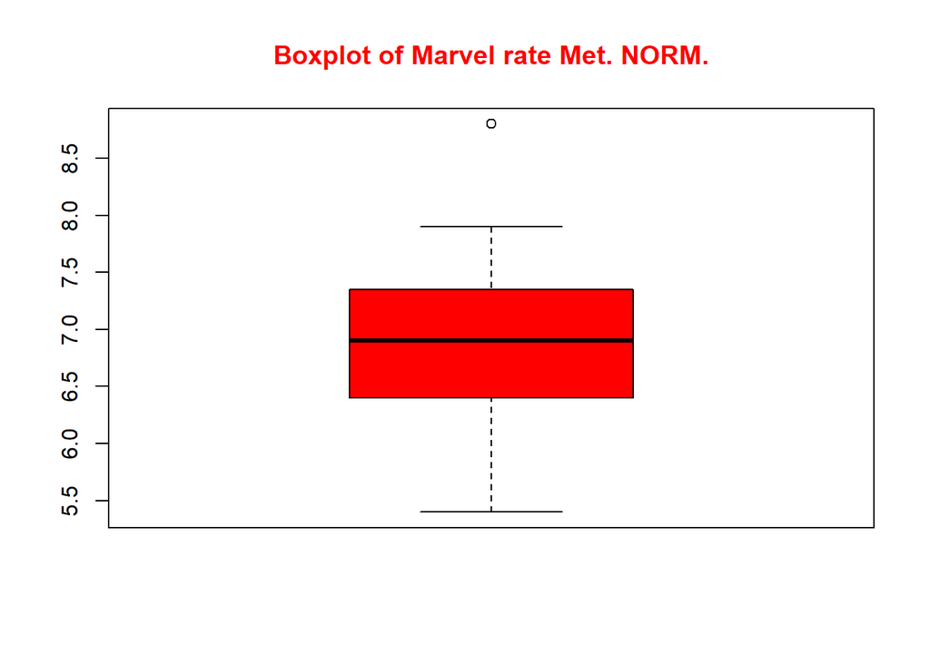

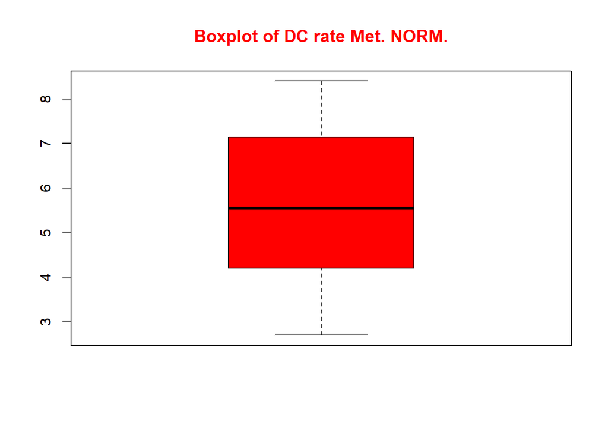

```
$DC
   Min. 1st Qu.  Median    Mean 3rd Qu.    Max.
  3.300   6.000   7.050   6.806   7.750   9.000

$Marvel
   Min. 1st Qu.  Median    Mean 3rd Qu.    Max.
  6.700   7.050   7.400   7.478   7.850   8.500
```

```
$DC
   Min. 1st Qu.  Median    Mean 3rd Qu.    Max.
  2.700   4.300   5.550   5.650   7.125   8.400

$Marvel
   Min. 1st Qu.  Median    Mean 3rd Qu.    Max.
  5.400   6.400   6.900   6.865   7.350   8.800
```

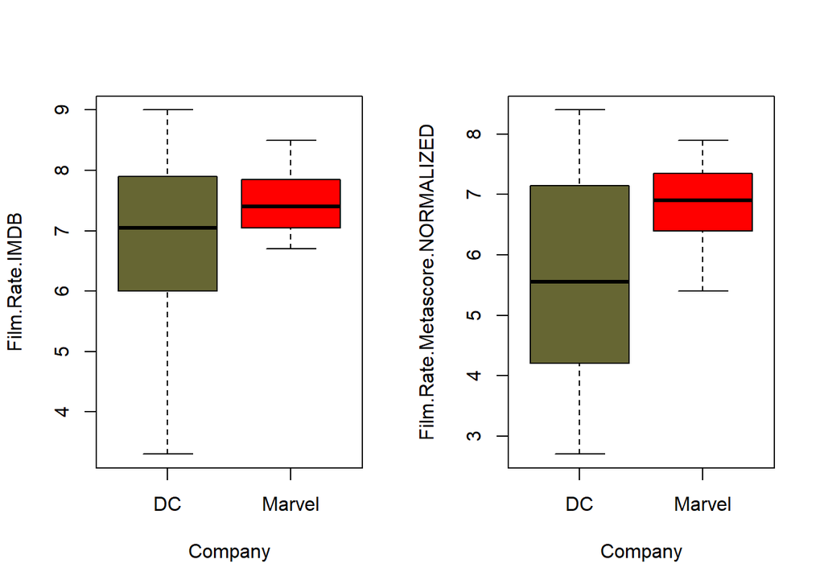

#### *Si deduce che per entrambi i siti di riferimento , per la recezione di dati relativi alla valutazione, hanno valutato un numero maggiore di fim Marvel più positivamente rispetto a quelli DC*.

### *Verifico, infine, la correlazione tra la variabile Film.Rate.IMDB e Film.Rate.Metascore, realizzando ,successivamente, il grafico di dispersione.*

```r
Df.voti=MCU_vs_DCU.df[,c(4,5)]
Mat.voti=as.matrix(Df.voti)
cor.mat.voti=cor(Mat.voti)
cor.mat.voti
```

```
               Rate Metascore
Rate      1.0000000 0.7869007
Metascore 0.7869007 1.0000000
```

```
Call:
lm(formula = MCU_vs_DCU.df$Metascore ~ MCU_vs_DCU.df$Rate)

Residuals:
    Min      1Q  Median      3Q     Max
-19.864  -5.932   1.285   4.755  23.345

Coefficients:
                   Estimate Std. Error t value Pr(>|t|)
(Intercept)          -9.432      9.525  -0.990    0.329
MCU_vs_DCU.df$Rate   10.149      1.308   7.757 2.85e-09 ***
---
Signif. codes:  0 '***' 0.001 '**' 0.01 '*' 0.05 '.' 0.1 ' ' 1

Residual standard error: 8.668 on 37 degrees of freedom
Multiple R-squared:  0.6192,    Adjusted R-squared:  0.6089
F-statistic: 60.17 on 1 and 37 DF,  p-value: 2.851e-09
```

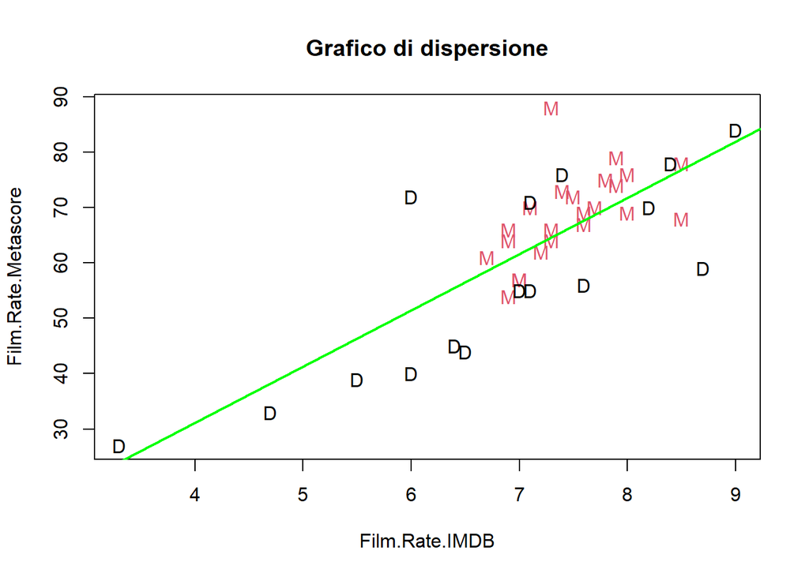

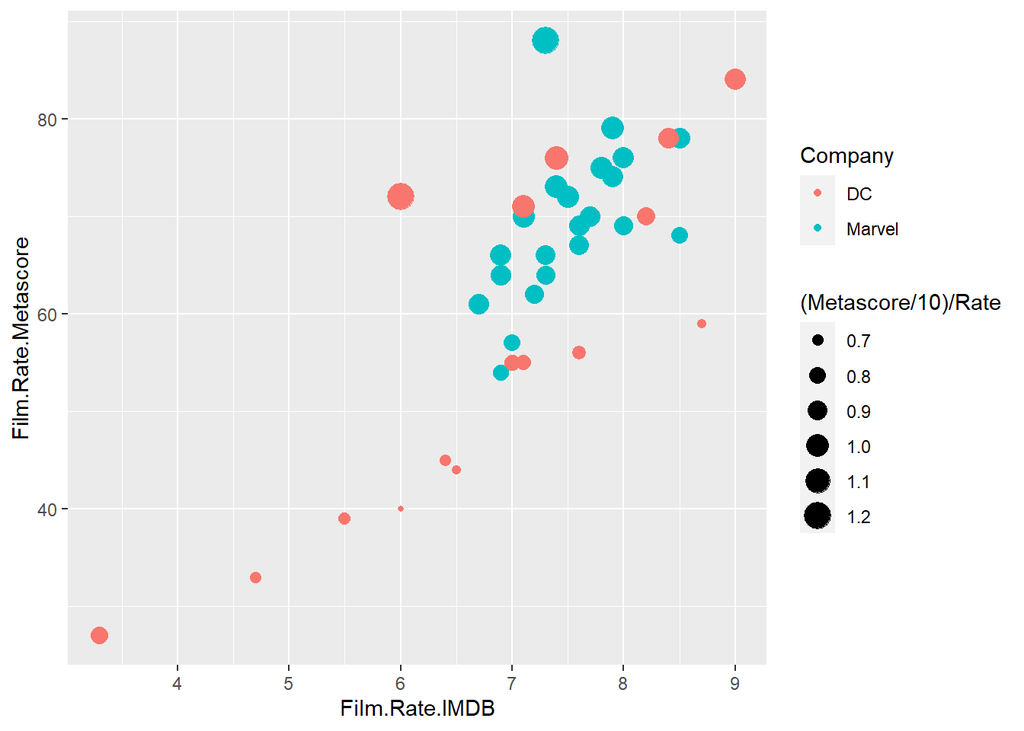

#### *Si nota,quindi, che la correlazione tra Film.Rate.IMDB E Film.Rate.Metascore è molto alta, pertanto mi vuol quanto è forte il legame tra Film.Rate.Metascore e Film.Rate.IMDB quando sono paritarie*

## **VARIABILE FILM.MINUTES**

### *Analizzo il summary della variabile Film.Minutes per dedurre il range di valori che assume.*

```
 [1] 126 112 124 115 124 143 130 112 136 121 141 117 147 115 136 133 130 134 149
[20] 118 123 181 129 104 140 154 152 162  81 114 164 143 151 123 141 120 143 132
[39] 122
```

```
   Min. 1st Qu.  Median    Mean 3rd Qu.    Max.
   81.0   120.5   130.0   131.8   143.0   181.0
```

### *Analizzo il summary della variabile Film.Minutes categorizzata in base alla variabile Company per dedurre il range di valori che assume.*

#### Marvel

```
   Min. 1st Qu.  Median    Mean 3rd Qu.    Max.
  112.0   119.5   129.0   130.3   136.0   181.0
```

#### DC

```
   Min. 1st Qu.  Median    Mean 3rd Qu.    Max.
   81.0   121.5   140.5   134.1   151.2   164.0
```

### *Creiamo quindi boxplot e istogrammi che ci facciano intuire in maniera piu chiara la distribuzione della variabile Film.Minutes geerica e della variabile Film.Minutes categorizzata per i film Marvel DC.*

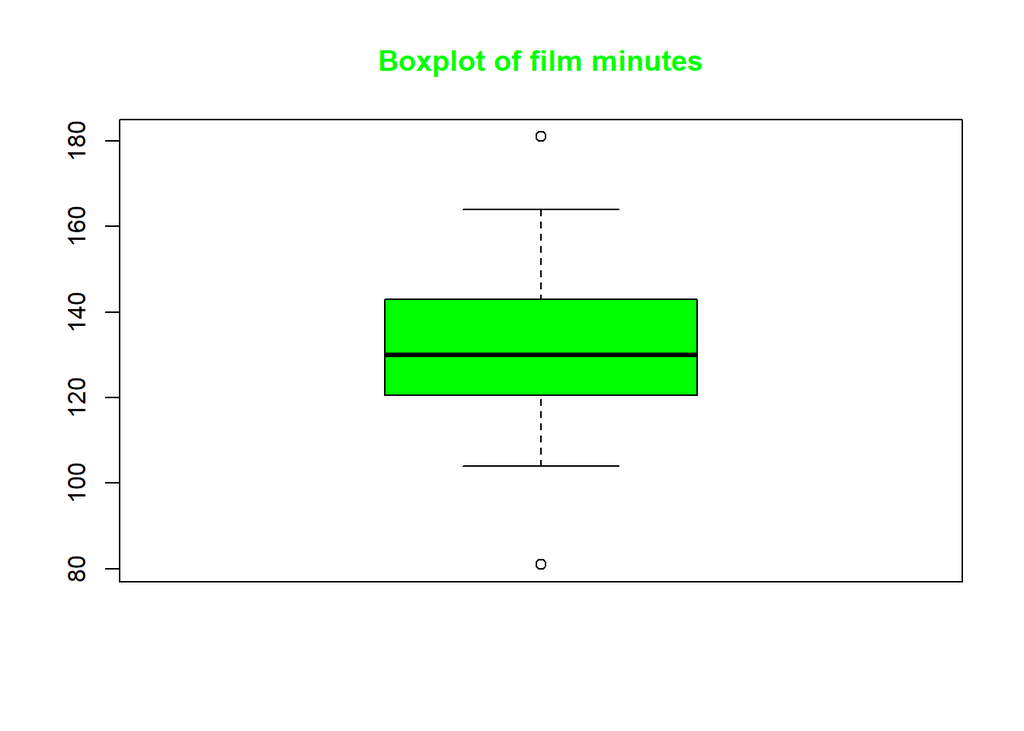

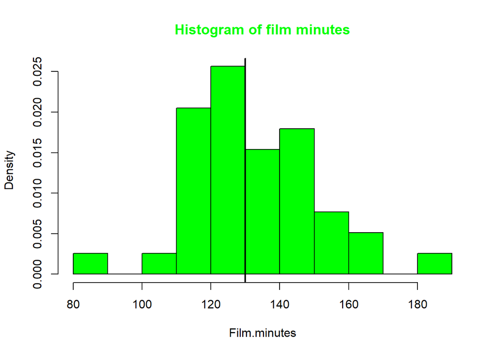

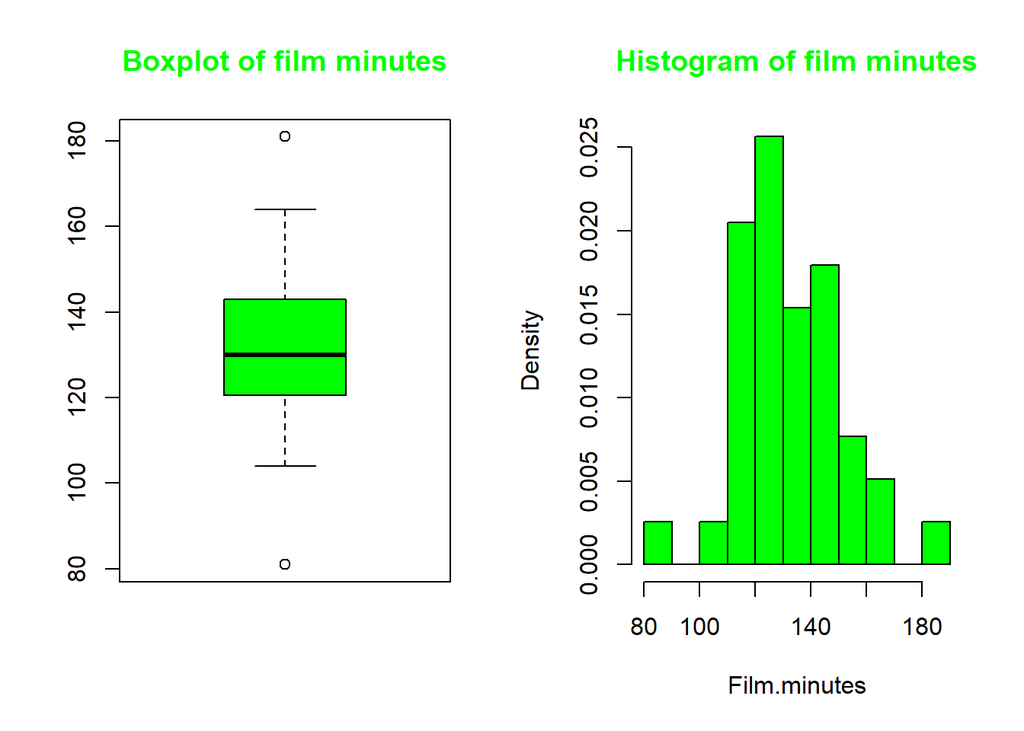

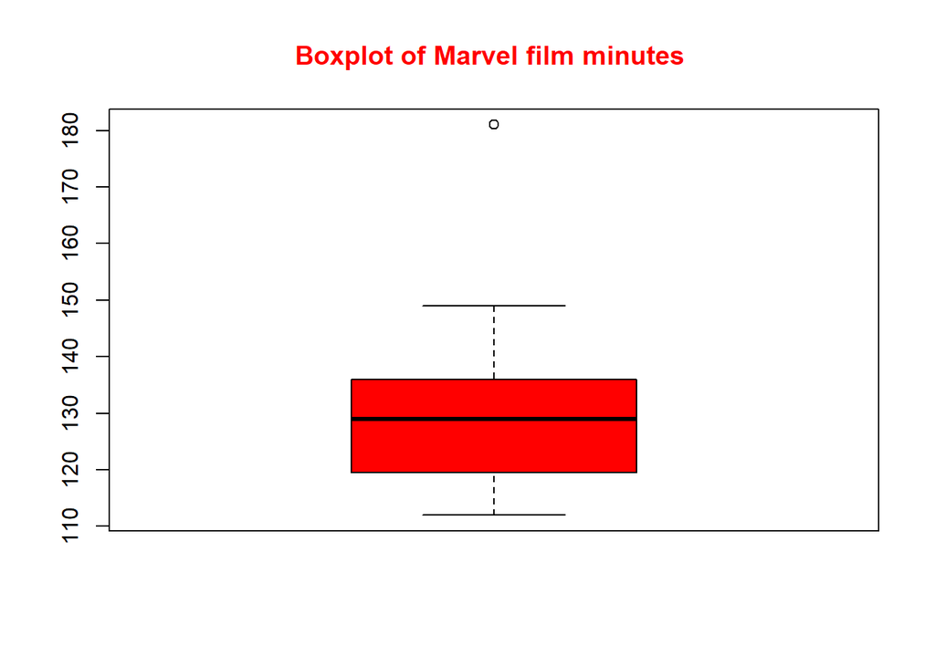

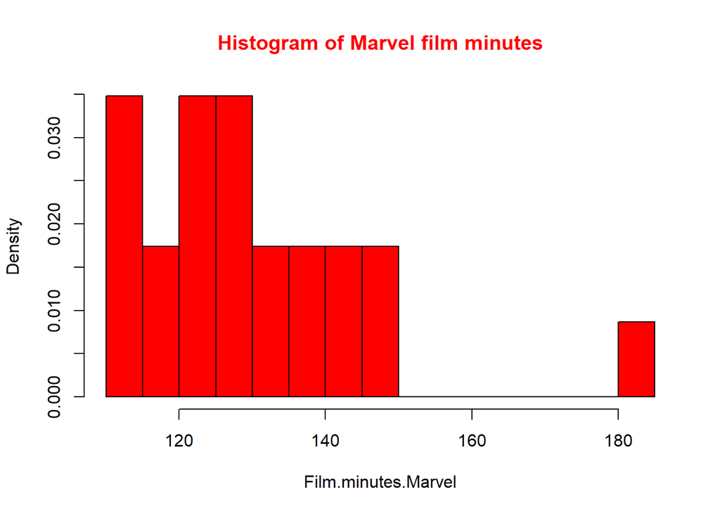